# Assignment 2

Gunneet Singh

04/23/2022

# Breaking Bad (American TV Series)

## A Brief Description

*Breaking Bad* is an American neo-Western crime drama television series created and produced by *Vince Gilligan*. The show aired on AMC from January 20, 2008, to September 29, 2013, consisting of five seasons for a total of 62 episodes. It was set and filmed in Albuquerque, New Mexico, and tells the story of Walter White (*Bryan Cranston*), an underpaid, overqualified, and dispirited high-school chemistry teacher who is struggling with a recent diagnosis of stage-three lung cancer. *Walter* turns to a life of crime, partnering with his former student Jesse Pinkman (*Aaron Paul*), by producing and distributing crystal meth to secure his family’s financial future before he dies, while navigating the dangers of the criminal underworld. According to *Gilligan*, the title is a Southern colloquialism meaning “to raise hell”.

Among the show’s co-stars are *Anna Gunn* and *RJ Mitte* as Walter’s wife Skyler and son Walter Jr., and *Betsy Brandt* and *Dean Norris* as Skyler’s sister Marie Schrader and her husband Hank, a DEA agent. Others include *Bob Odenkirk* as Walter’s and Jesse’s sleazy lawyer Saul Goodman, *Jonathan Banks* as private investigator and fixer Mike Ehrmantraut, and *Giancarlo Esposito* as drug kingpin Gus Fring. The final season introduces *Jesse Plemons* as the criminally ambitious Todd Alquist, and *Laura Fraser* as Lydia Rodarte-Quayle, a cunning business executive secretly managing Walter’s global meth sales for her company.

Breaking Bad’s first season received generally positive reviews, while the rest of its run received unanimous critical acclaim. Since its conclusion, the show has been lauded by critics as one of the greatest television series of all time. It had fair viewership in its first three seasons, but the fourth and fifth seasons saw a moderate rise in viewership when it was made available on Netflix just before the fourth season premiere. Viewership increased more drastically upon the premiere of the second half of the fifth season in 2013. By the time that the series finale aired, it was among the most-watched cable shows on American television. The show received numerous awards, including 16 Primetime Emmy Awards, eight Satellite Awards, two Golden Globe Awards, two Peabody Awards, two Critics’ Choice Awards, and four Television Critics Association Awards. *Cranston* won the Primetime Emmy Award for Outstanding Lead Actor in a Drama Series four times, while *Aaron Paul* won the Primetime Emmy Award for Outstanding Supporting Actor in a Drama Series three times; *Anna Gunn* won the Primetime Emmy Award for Outstanding Supporting Actress in a Drama Series twice. In 2013, Breaking Bad entered the *Guinness World Records* as the most critically acclaimed TV show of all-time.[11]

(Source: [Wikipedia](https://en.wikipedia.org/wiki/Breaking_Bad))

## Some pictures from the Breaking Bad

[figure not shown]

*Breaking Bad*

[figure not shown]

*A random snippet from the series*

## Basic Statistical analysis

Due to the limited data provided by Wikipedia, it was not possible to perform Data analysis. As a result, the following charts gathered from different sources provide statistical information regarding the legendary TV series.

### Viewership across episodes

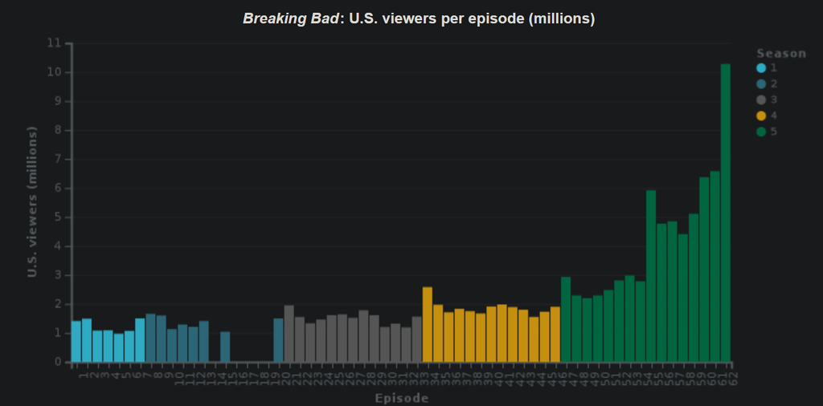

([Source](https://www.reddit.com/r/breakingbad/comments/fpztha/breaking_bad_us_viewers_per_episode_millions/))

### Ratings over time

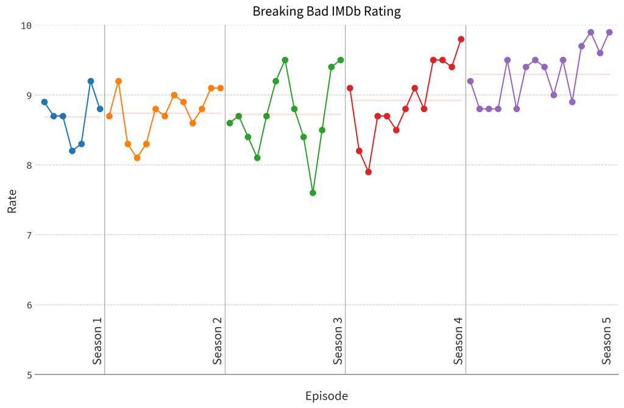

*Breaking Bad episode wise IMDB ratings*

([Source](https://www.reddit.com/r/dataisbeautiful/comments/bo0z3v/oc_breaking_bad_imdb_rating/))